# Clustering y expresión diferencial

Qué se puede afirmar y qué no a partir de un cluster

Dr. Danilo Ceschin

Bioinformática y Estadística 3 · Licenciatura en Ciencias Genómicas

Clase 2 de 4 · 10 de septiembre de 2026

## Esta clase tiene dos mitades

Encuadre

**Primera mitad: mecánica**  
Cómo se construye el grafo de vecinos, qué hace un algoritmo de detección de comunidades, qué significa el parámetro de resolución. Es la parte que aparece en todos los tutoriales.

**Segunda mitad: estadística**  
Por qué el procedimiento estándar para encontrar marcadores de cluster produce falsos positivos a una tasa que no controlamos. Es la parte que casi nunca aparece, y es la razón de que esta materia se llame Bioinformática **y Estadística**.

La frase de la clase

#### Clusterizar y después testear con los mismos datos

Cuando definimos grupos usando ciertos datos y después testeamos si esos grupos difieren usando **los mismos datos**, los p-valores que obtenemos no son p-valores.

Este procedimiento está en el tutorial oficial de casi todos los paquetes de single-cell.

Hoy lo vamos a demostrar empíricamente, sobre datos que sabemos que no tienen ninguna estructura.

## Clustering basado en grafos

Primera parte

Por qué no usamos k-means.

## ¿Por qué no k-means?

Elección del método

k-means, k-medoids y el clustering jerárquico suponen grupos **aproximadamente esféricos y de tamaño comparable**. Las poblaciones celulares no cumplen ninguna de las dos condiciones.

- Hay tipos celulares con 4.000 células y tipos con 40 en el mismo experimento.
- Muchos tienen forma alargada porque contienen un gradiente continuo de estados (naive → memoria → efector).
- Además, k-means exige fijar *k* de antemano, que es justamente lo que queremos averiguar.

La alternativa

#### Detección de comunidades en un grafo

No hace ningún supuesto sobre la forma ni el tamaño de los grupos.

Escala bien: hoy se aplica de rutina a millones de células.

Es el estándar en single-cell desde ~2015 y lo usan tanto Seurat como Scanpy.

## Lo que k-means le hace a una población pequeña

Elección del método · en los datos del curso

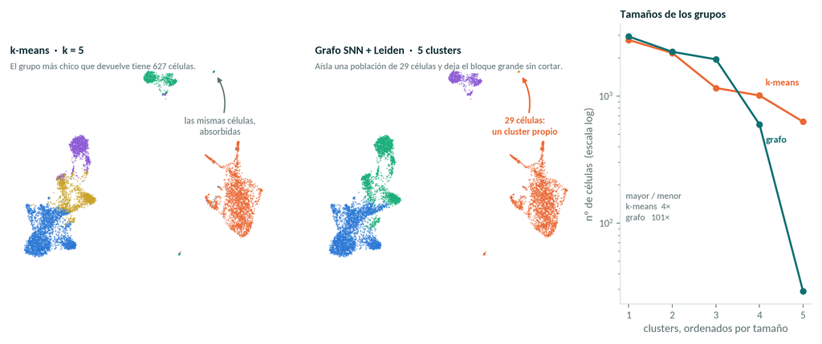

Las mismas células del curso, el mismo espacio de PCA de 30 componentes y el MISMO número de grupos (k = 5). Lo único que cambia es el algoritmo. k-means busca particiones convexas y de tamaño parecido: parte en dos el bloque grande y se traga la población de 29 células. Panel derecho: el grupo mayor y el menor difieren 101× en el grafo y solo 4× en k-means. ARI entre ambas particiones: 0,81.

## Tres pasos

Mecánica

**1 · Grafo KNN**  
Cada célula se conecta con sus `k` vecinos más cercanos **en el espacio de PCA**. La elección de `dims` de la clase 1 vuelve a aparecer aquí, y esta vez determina literalmente quién es vecino de quién. Parámetro: `k.param` (por defecto 20).

**2 · Grafo SNN** *(shared nearest neighbors)*  
El peso de la arista entre dos células pasa a ser **cuántos vecinos comparten**. Esto suaviza el ruido: dos células conectadas por casualidad rara vez comparten muchos vecinos. `FindNeighbors()` construye los dos grafos.

**3 · Detección de comunidades**  
Se busca la partición que maximiza la **modularidad**: muchas aristas dentro de los grupos, pocas entre grupos. `FindClusters()` ofrece cuatro algoritmos.

## Del espacio de PCA al grafo, y del grafo a los clusters

Mecánica · en los datos del curso

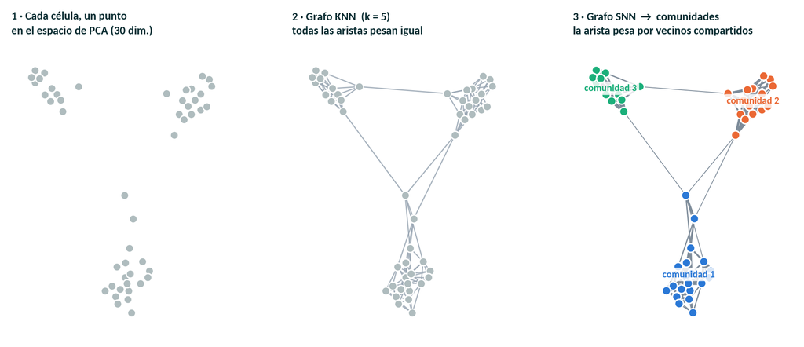

48 células reales, submuestreadas para que el grafo se lea. El grafo se construye en el espacio de PCA de 30 dimensiones, no en el plano del dibujo. En el paso 3 la arista pesa por vecinos compartidos: las conexiones por azar se debilitan solas.

## Louvain vs Leiden

Algoritmos

#### Louvain (`algorithm = 1`)

- El clásico, por defecto en Seurat.
- Rápido y bien establecido.
- ⚠ Puede producir comunidades **internamente desconectadas**: grupos que declara como una unidad pero que en el grafo no están conectados entre sí.
- Ese defecto no es teórico: aparece en datasets reales.

#### Leiden (`algorithm = 4`)

- Garantiza que todas las comunidades estén conectadas.
- En general produce particiones de mayor calidad.
- Antes exigía Python (`reticulate` + `leidenalg`): la principal fuente de problemas de instalación.
- ✅ Desde Seurat 5.3.1 corre en R puro: `FindClusters(algorithm = 4, leiden_method = "igraph")`.

**Recomendación para el curso:** usar Leiden. La actualización de Seurat elimina la única razón práctica que había para no hacerlo.

## La resolución

El parámetro que más importa

Valores bajos → pocos clusters grandes. Valores altos → muchos clusters chicos.

**No existe la resolución correcta.** La resolución define la pregunta que estás haciendo.

*“¿Cuántos tipos celulares hay?”* no tiene una respuesta única: depende de si quieres distinguir *linfocito T* de *monocito*, o *T CD4 naive* de *T CD4 de memoria central*.

Lo que sí se puede hacer: elegir con criterio, verificar la estabilidad y **reportar la elección**. La herramienta es `clustree`, que muestra cómo se reorganizan las células al aumentar la resolución.

Cómo se lee un clustree

#### Refinar vs reorganizar

Un cluster que se divide limpiamente en dos, y esos dos se mantienen estables hacia abajo → **subestructura real**.

Un nodo que recibe flechas de **varios** clusters de la fila anterior → el algoritmo está reorganizando células, no refinando grupos. Eso es sobre-clusterización.

Regla práctica: quédate en la resolución más alta **antes** de que aparezcan los cruces masivos.

## La resolución no descubre el número de clusters: lo define

El parámetro que más importa · en los datos del curso

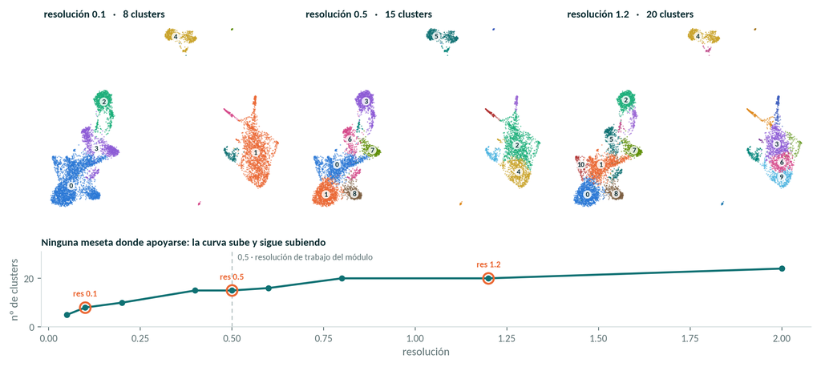

## El problema estadístico

Segunda parte

Doble inmersión: *double dipping*.

## La circularidad

Reconstruyamos qué hicimos

**1 · Usamos la expresión de ~2.000 genes para construir el grafo**  
Los mismos genes que después vamos a testear.

**2 · Buscamos la partición que MAXIMIZA la separación entre grupos**  
El algoritmo de modularidad hace exactamente eso: encuentra el corte que hace más distintos a los grupos.

**3 · Ahora testeamos si esos genes difieren entre esos grupos**  
La hipótesis nula del test de Wilcoxon —*“estas dos muestras vienen de la misma distribución”*— ya fue violada **por construcción**, no por la biología.

## Clusterizamos ruido puro

Demostración

Matriz de conteos de Poisson con la misma tasa para todas las células: sin grupos, sin genes diferenciales, sin nada.

0grupos verdaderos en los datos simulados

6–9clusters que el algoritmo encuentra igual, con UMAP separado y todo

decenasde “marcadores” con p ajustado < 0,05 — todos falsos positivos, y más cuantas más células

El clustering **siempre** devuelve clusters. Nunca dice “aquí no hay grupos”.

## Distribución de p-valores bajo la hipótesis nula

La comparación decisiva

Mismos datos (ruido). Lo único que cambia es de dónde salieron los grupos.

#### Grupos derivados de los datos

- Clusterizamos y después testeamos.
- Los p-valores se apilan contra cero.
- Aparecen p-valores de 1e-10 y menores.
- Falsos positivos masivos, sin ninguna estructura real que los justifique.

#### Grupos asignados al azar

- Etiquetamos A/B al azar, sin clusterizar.
- Distribución **uniforme** de p-valores.
- Exactamente lo que predice la teoría bajo H₀ verdadera.
- El test funciona perfectamente: el problema nunca fue el test.

El error no está en el test de Wilcoxon. Está en usarlo sobre grupos que se definieron **para maximizar la diferencia que después se testea**.

## Los dos histogramas, sobre la misma matriz de ruido

La comparación decisiva · medida

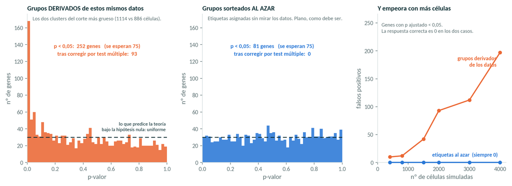

La MISMA matriz de conteos de Poisson sin ninguna estructura: la respuesta correcta es cero en los tres paneles. Mismo test, mismo contraste, mismo número de células por grupo. Lo único que cambia entre el primer panel y el segundo es SI LAS ETIQUETAS SE DERIVARON de los datos que después se testean. El tercer panel muestra que aumentar el número de células no arregla el problema: lo agrava.

## Cada pregunta tiene su herramienta

Qué hacer entonces

| Qué quieres hacer | Herramienta correcta | Advertencia |
| --- | --- | --- |
| Ordenar candidatos a marcador de un cluster | `FindAllMarkers` está bien | Usa el ranking, no reportes los p-valores como evidencia |
| Testear si un cluster es un grupo real | `ClusterDE` (control sintético) o *count splitting* | Publicados 2023–2026; todavía poco usados |
| Comparar condiciones dentro de un tipo celular | Pseudobulk + DESeq2 / edgeR / limma | Requiere ≥ 3 réplicas biológicas por condición |
| Comparar abundancia de tipos celulares | `miloR`, `scCODA`, `propeller` | Es una pregunta composicional, no de expresión |
| Validar un marcador | Datos independientes: otro dataset, citometría, IHC | No hay atajo estadístico para esto |

**Regla operativa del curso:** en scRNA-seq, un p-valor de `FindAllMarkers` es una medida de **ranking**, no una probabilidad de error de tipo I.

## Los tres argumentos que deciden qué marcadores ves

En la práctica

| Argumento | Qué hace | Cuidado |
| --- | --- | --- |
| `only.pos = TRUE` | Devuelve solo genes **enriquecidos** en el cluster | Trunca la distribución de p-valores: no lo uses si vas a mirar el histograma |
| `min.pct = 0.25` | Exige detección en ≥ 25 % de las células de algún grupo | Descarta marcadores de poblaciones muy chicas dentro del cluster |
| `logfc.threshold = 0.5` | Exige un cambio mínimo antes de testear | Es un filtro de tamaño de efecto, no de significancia: acelera y reduce el testeo múltiple |
| `presto` | Acelera ~100× el test de Wilcoxon | Seurat lo detecta solo si está instalado; no cambia el resultado, solo el tiempo |
| Cómo se leen las figuras | `DotPlot`: tamaño = % de células que lo expresan, color = expresión media escalada | `Heatmap`: célula a célula, sirve para ver si el marcador es de TODO el cluster o de una parte |

Ninguno de estos argumentos es neutral: cada uno decide qué genes llegan siquiera a ser testeados. **Reportarlos es parte del resultado.**

## Comparar condiciones

Tercera parte

El segundo problema estadístico, independiente del primero.

## Las células de una muestra no son réplicas

Pseudorreplicación

*“Dentro de los monocitos, ¿qué genes cambian entre pacientes y controles?”*

Tienes 3 pacientes y 3 controles. De cada uno recuperas 2.000 monocitos. Un test célula a célula ve **6.000 vs 6.000** observaciones.

Pero las 2.000 células de un paciente no son 2.000 réplicas: comparten genotipo, tratamiento, hora de extracción, lote de procesamiento. Son *pseudorréplicas*.

**El tamaño muestral real es 3 vs 3.** Al ignorarlo, los p-valores se vuelven astronómicamente chicos y aparecen cientos de “genes diferenciales” que son variación entre individuos.

Dato de la viñeta oficial de Seurat

#### 1.649 genes

aparecen como diferenciales en el análisis célula a célula y **no** lo son en el análisis pseudobulk del mismo dataset.

No es un caso patológico elegido a propósito: es el ejemplo que la propia documentación de Seurat usa para explicar el problema.

## Pseudobulk

La solución

Sumar los conteos de todas las células del mismo tipo celular dentro de cada muestra.

Una muestra × un tipo celular = **un perfil de expresión**.

Con eso se recupera un diseño de RNA-seq bulk clásico, y se aplican métodos con quince años de validación: DESeq2, edgeR, limma-voom.

En Seurat v5: `AggregateExpression(obj, group.by = c("tipo", "muestra"))`.

No es más conservador porque sí: **es el método que responde la pregunta que uno cree estar haciendo.**

Requisito 1

#### ≥ 3 réplicas biológicas por condición

Individuos distintos. Dos pocillos del mismo donante no son dos réplicas.

Requisito 2

#### Suficientes células por muestra y tipo

~20 como mínimo grosero. Con menos, el perfil agregado es inestable.

Ojo con

#### La composición

Si una condición tiene muchas más células de un tipo, eso es un resultado en sí mismo y se analiza aparte.

## Mismo dato, misma pregunta, dos unidades experimentales

Pseudorreplicación · simulación

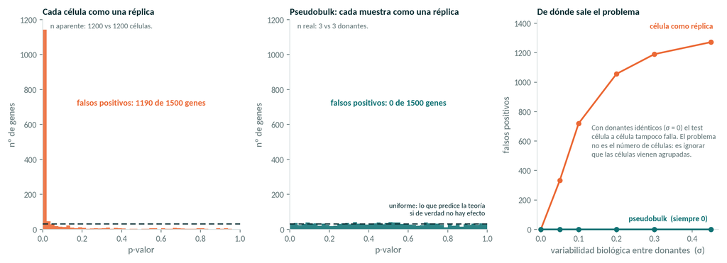

Simulación de 6 donantes, 3 control y 3 tratado, 400 células cada uno, y NINGÚN efecto de condición: los genes solo varían entre donantes, como en cualquier experimento real. La respuesta correcta es cero en los dos primeros paneles. Tratar cada célula como una réplica declara diferencial a la mayor parte del transcriptoma; agregar por muestra y testear 3 contra 3 no encuentra nada, que es lo correcto.

## Cinco cosas

Síntesis

1. **El clustering por grafos no supone forma ni tamaño** de los clusters. Leiden es preferible a Louvain, y desde Seurat 5.3.1 corre en R puro.
2. **La resolución define la pregunta.** Se elige con criterio y se reporta.
3. **El clustering siempre devuelve clusters**, incluso sobre ruido puro.
4. **Los p-valores post-clustering no son p-valores.** Sirven para rankear candidatos.
5. **Para comparar condiciones: pseudobulk.** Las células de una muestra no son réplicas independientes.

El martes 22 le ponemos nombre biológico a estos clusters — y vamos a ver que ese nombre también es una hipótesis.

Inicio